Text Mining- Customer Query Classification Wen-Shiuan Liang 11/17, 2018

# Part (II) Query Classification

### Introduction

**In the last part, We have accomplished text preprocessing and transfromation. With Document-Term Matrix (DTM), we explore the customer query with wordcloud and topic model&network chart. By analyzing the network chart, we digged out some common questions appear in customer query. We later labeled every query with specific question. Now in this part, we are going to leverage machine learning algorithms and make a query classifier**

```
## # tmcn Version: 0.1-4
```

```
## # Version: 0.2-1
```

### Text Preprocessing

#### Data Outlook

```
##                                                                                          content
## 1                                                                        請問憑證作業時程要多久?
## 2                                             明白。那請問何時才收到入場門票及快證確認？\n謝謝。
## 3                                                                         請問何時可以收到門票？
## 4                                             你好，信箱尚未收到票券，可否麻煩再寄送一次，謝謝你
## 5                                         你好，請問門票何時有？我星期一出發了, 請盡快跟進。Thx!
## 6 請問最遲星期一(11月6日)收到貨嗎？因為我快將出發。\n電子憑證會email給我？\n請提供熱線電話。Thx!
##   label
## 1     1
## 2     1
## 3     1
## 4     1
## 5     1
## 6     1
```

By analyzing the topic model, we manually define 4 different types of questions that customer frequently ask for 7781 (Universal Studio). They are: - 1: Voucher Confirm/Receive (Haven’t received voucher) - 2: Question Related to the Voucher (How to use? Need to print?) - 3: Different Session Related Question (Mainly about Harry Potter events) - 0: Other Question

#### Count of Each Type of Question

```r
table(data$label)
```

```
##
##    0    1    2    3
## 1540 1071  540  345
```

### Text Preprocessing & Transformation

#### Filtering

```r
data2 =  data[nchar(data$content)>=6,]
data2 = data2[which(!duplicated(data2$content)),]
#Transform english letter into lower case
data2[,1] = tolower(data2[,1])
#Transform all Chinese into Simplified Chinese
data2[,1] = toTrad(data2[,1],rev = T)
df_note = data2[grep('note :',data2[,1]),]
if (nrow(df_note)!=0){
  data2 = data2[-grep('note :',data2[,1]),]
}else{
  data2 = data2
}
```

#### Segmentation

```r
corpus = Corpus(VectorSource(data2[,1]))
#Cleaning upper class, number, punctuation
corpus = tm_map(corpus, content_transformer(tolower))
corpus = tm_map(corpus, removePunctuation)
corpus = tm_map(corpus, removeWords, stopwords())
corpus = tm_map(corpus, stemDocument, language = "english")
corpus = tm_map(corpus, function(word) {
  gsub("[0-9]", "", word)
})

library(tmcn)
corpus = tm_map(corpus, toTrad,rev = TRUE)
#segmentation
d.corpus <- tm_map(corpus, segmentCN, nature = TRUE)

d.corpus <- VCorpus(VectorSource(d.corpus))
text = tm_map(d.corpus, stripWhitespace)
```

#### Creating Document-Term Matrix

```r
dtm = DocumentTermMatrix(text,control = list(wordLengths = c(1, Inf),bounds = list( global = c(3,Inf),local=c(1,Inf)),weighting = weightTfIdf))
dataset = as.data.frame(as.matrix(dtm))
dff = dataset
dataset$label = data2$'label'
dataset$label = factor(dataset$label, levels = c(0,1,2,3))
```

### Samle Split

```r
library(caTools)
set.seed(123)
split = sample.split(dataset$label, SplitRatio = 9/10)
training_set = subset(dataset, split == TRUE)
test_set = subset(dataset, split == FALSE)
n = dim(training_set)[2]
```

### Feature Selection

#### F1 Score

```r
f1_score <- function(predicted, expected, positive.class="1") {
  cm = as.matrix(table(expected, predicted))
  precision <- diag(cm) / colSums(cm)
  recall <- diag(cm) / rowSums(cm)
  f1 <-  ifelse(precision + recall == 0, 0, 2 * precision * recall / (precision + recall))

  #Assuming that F1 is zero when it's not possible compute it
  f1[is.na(f1)] <- 0

  #Binary F1 or Multi-class macro-averaged F1
  ifelse(nlevels(expected) == 2, f1[positive.class], mean(f1))
}
```

### Classification Algorithms

#### Random Forest

```r
library(ranger)
library(caret)
folds = createFolds(training_set$label, k = 10)
cv = lapply(folds, function(x) {
  training_fold = training_set[-x, ]
  test_fold = training_set[x, ]
  classifier = ranger(dependent.variable.name = 'label',
                      data = training_fold)
  # Predicting the Test set results
  y_pred = predict(classifier, data = test_fold[-n])$predictions
  cm = table(test_fold[, n], y_pred)
  accuracy = sum(diag(cm))/sum(cm)
  f1 = f1_score(y_pred,test_fold[,n])
  return(list(accuracy=accuracy, cm = cm,f1 = f1))
})

predict2 = c(mean(unlist(lapply(cv, function(x) {
  return(x$accuracy)}))),mean(unlist(lapply(cv, function(x) {
    return(x$f1)}))))
cv
```

```
## $Fold01
## $Fold01$accuracy
## [1] 0.7518797
##
## $Fold01$cm
##    y_pred
##      0  1  2  3
##   0 86 16  3  4
##   1 13 68  3  1
##   2 10 11 25  2
##   3  2  0  1 21
##
## $Fold01$f1
## [1] 0.7425165
##
##
## $Fold02
## $Fold02$accuracy
## [1] 0.8598485
##
## $Fold02$cm
##    y_pred
##      0  1  2  3
##   0 91 10  4  3
##   1  8 74  3  0
##   2  4  2 41  0
##   3  1  1  1 21
##
## $Fold02$f1
## [1] 0.8620306
##
##
## $Fold03
## $Fold03$accuracy
## [1] 0.8120301
##
## $Fold03$cm
##    y_pred
##      0  1  2  3
##   0 93 11  2  3
```

[output cut: 103 more lines]

```
##
## $Fold10
## $Fold10$accuracy
## [1] 0.8157895
##
## $Fold10$cm
##    y_pred
##      0  1  2  3
##   0 93 14  2  0
##   1 11 71  3  0
##   2  9  3 32  4
##   3  1  2  0 21
##
## $Fold10$f1
## [1] 0.8138983
```

```r
predict2
```

```
## [1] 0.8099105 0.7997878
```

We used accuracy and F1 score to analyze our model performance. The accuracy and F1 score is 81%, 80% respectively, which is pretty good for a four category classifier.

#### Ridge Regression

```r
library(glmnet)
```

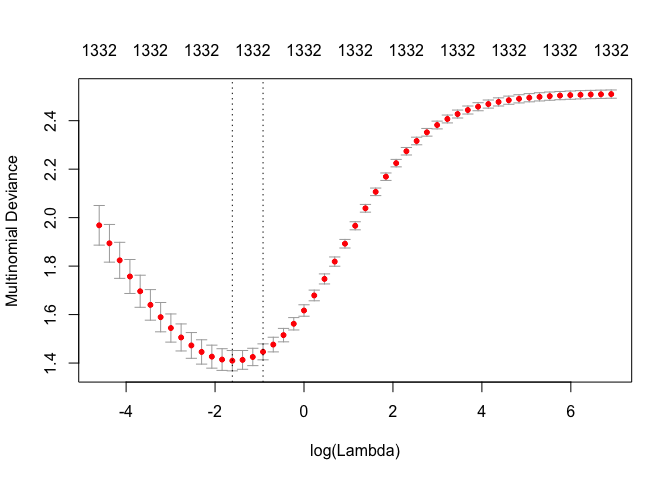

```r
lambdas <- 10^seq(3, -2, by = -.1)
cv_fit <- cv.glmnet(x = data.matrix(training_set[,-n]),y = data.matrix(training_set[,n]) , alpha = 0, lambda = lambdas,family="multinomial")
plot(cv_fit)
```

```r
best_lambda <- cv_fit$lambda.min
```

#### Predicting the Test set results

```r
y_p <- as.numeric(predict(cv_fit, s = best_lambda, newx = data.matrix(test_set[,-n]),type="class"))
cm = table(test_set[,n],y_p)
(accuracy = sum(diag(cm))/sum(cm))
```

```
## [1] 0.7346939
```

```r
(f1 = f1_score(y_p,test_set[,n]))
```

```
## [1] 0.711074
```

### Out Sample Performance

```r
rf = ranger(label~., data = training_set)
p1 = predict(rf,data = test_set[,-ncol(test_set)])$predictions
rf$confusion.matrix
```

```
##     predicted
## true   0   1   2   3
##    0 919 112  38  18
##    1 101 710  33   4
##    2  83  49 326  20
##    3  30   7   9 192
```

```r
cm = confusionMatrix(p1,test_set[,'label'])
(F1 = f1_score(p1,test_set[,'label']))
```

```
## [1] 0.7770402
```

```r
(accuracy = sum(diag(cm$table))/sum(cm$table))
```

```
## [1] 0.792517
```

### Conclusion

Next step we are going to leverage feature selection and ensemble modeling to increase performance while maintain the efficiency